# Week 12 — Double Machine Learning

From FWL to Valid Causal Inference at Scale

Author

Tom Hackenberg · Block 2

Published

April 28, 2025

> **This notebook accompanies the Week 12 lecture.** All code is complete and will run as-is. The interpretation cells — marked with 📝 — are intentionally left for you to fill in during and after the session. The projected version in the lecture contains the answers.

## Setup

```python
import numpy as np
import pandas as pd
import statsmodels.api as sm
import matplotlib.pyplot as plt
from sklearn.ensemble import RandomForestRegressor
from sklearn.model_selection import KFold

plt.rcParams.update({
    "figure.facecolor": "white",
    "axes.facecolor":   "#f8fafc",
    "axes.spines.top":  False,
    "axes.spines.right":False,
    "font.size": 12,
})
```

## 1 · The Data

### The scenario

A retailer runs digital ad campaigns across 600 customers. We observe ad spend, sales, and six controls. The true average effect of £1k more in ad spend is known. This session our job is to recover it using DML, and understand why simpler methods fail.

```python
rng = np.random.default_rng(42)
n   = 600

# --- Controls ---
brand_awareness  = rng.normal(0, 1, n)
competitor_spend = rng.normal(0, 1, n)
seasonality      = np.sin(2 * np.pi * rng.uniform(0, 1, n))
customer_tenure  = rng.uniform(0, 10, n)
channel_mix      = rng.beta(2, 2, n)
region           = rng.choice([0.0, 0.3, -0.2], n)

X = np.column_stack([brand_awareness, competitor_spend, seasonality,
                     customer_tenure, channel_mix, region])
X_cols = ["brand_awareness","competitor_spend","seasonality",
          "customer_tenure","channel_mix","region"]

# --- Treatment: ad spend (£000s) ---
T = (2.0 * brand_awareness
   + 0.8 * brand_awareness**2
   + 1.0 * seasonality
   + region
   + rng.normal(0, 1, n))

# --- True heterogeneous effect ---
tau_i    = 2.5 - 0.14 * customer_tenure
tau_true = tau_i.mean()

# --- Outcome: sales revenue (£000s) ---
Y = (tau_i * T
   + 3.0 * brand_awareness
   + 1.5 * brand_awareness**2
   - 1.0 * competitor_spend
   + 2.0 * seasonality
   + 0.5 * customer_tenure
   + region
   + rng.normal(0, 1.5, n))

df = pd.DataFrame({"sales": Y, "ad_spend": T,
                   **dict(zip(X_cols, X.T))})

print(f"Observations: {n}")
print(f"True ATE:     £{tau_true:.2f}k per £1k ad spend")
print(f"Effect range: £{tau_i.min():.2f}k (high tenure) → £{tau_i.max():.2f}k (new customers)")
print(f"\nDataset preview:")
print(df.describe().round(2))
```

```
Observations: 600
True ATE:     £1.82k per £1k ad spend
Effect range: £1.10k (high tenure) → £2.50k (new customers)

Dataset preview:
        sales  ad_spend  brand_awareness  competitor_spend  seasonality  \
count  600.00    600.00           600.00            600.00       600.00
mean     5.54      0.81            -0.03             -0.02         0.02
std      8.96      2.63             0.97              1.00         0.70
min    -17.12     -4.91            -2.96             -3.65        -1.00
25%     -0.36     -1.00            -0.70             -0.64        -0.68
50%      3.83      0.39            -0.02              0.01         0.03
75%      9.50      1.95             0.59              0.62         0.71
max     56.87     13.64             2.91              3.18         1.00

       customer_tenure  channel_mix  region
count           600.00       600.00  600.00
mean              4.88         0.49    0.05
std               2.95         0.22    0.21
min               0.01         0.01   -0.20
25%               2.41         0.33   -0.20
50%               4.75         0.49    0.00
75%               7.53         0.67    0.30
max              10.00         0.98    0.30
```

**Tip**

📝 **Look at the summary statistics.** Before running any models. Some things to think about:

- Which controls are likely to be confounders (affect both ad spend and sales)?
- What does the range of `customer_tenure` tell you about the likely heterogeneity in the treatment effect?
- Why might `brand_awareness` be particularly problematic for a linear model?

## 2 · The Naïve Approach — OLS Without Controls

```python
T_s = pd.Series(T, name="ad_spend")
model_naive = sm.OLS(Y, sm.add_constant(T_s)).fit()
tau_naive   = model_naive.params["ad_spend"]

print(model_naive.summary().tables[1])
print(f"\nNaïve estimate:  £{tau_naive:.3f}k per £1k ad spend")
print(f"True ATE:        £{tau_true:.3f}k")
print(f"Bias:            {tau_naive - tau_true:+.3f}k")
```

```
==============================================================================
                 coef    std err          t      P>|t|      [0.025      0.975]
------------------------------------------------------------------------------
const          2.9387      0.127     23.092      0.000       2.689       3.189
ad_spend       3.2127      0.046     69.436      0.000       3.122       3.304
==============================================================================

Naïve estimate:  £3.213k per £1k ad spend
True ATE:        £1.817k
Bias:            +1.396k
```

**Tip**

📝 **Interpret this output.**

- The naïve estimate is £_**k. The true ATE is £**_k. The bias is ___k.
- The p-value is very small — does statistical significance guarantee that the estimate is correct?
- What is the most likely source of the bias, and in which direction does it push the estimate?

## 3 · Adding Controls — OLS with All Variables

```python
Xdf = pd.DataFrame(X, columns=X_cols)
Xdf.insert(0, "ad_spend", T)

model_ctrl = sm.OLS(Y, sm.add_constant(Xdf)).fit()
tau_ctrl   = model_ctrl.params["ad_spend"]

print(model_ctrl.summary().tables[1])
print(f"\nOLS + controls:  £{tau_ctrl:.3f}k per £1k ad spend")
print(f"True ATE:        £{tau_true:.3f}k")
print(f"Bias:            {tau_ctrl - tau_true:+.3f}k")
```

```
====================================================================================
                       coef    std err          t      P>|t|      [0.025      0.975]
------------------------------------------------------------------------------------
const                1.0758      0.288      3.731      0.000       0.510       1.642
ad_spend             2.8425      0.065     43.420      0.000       2.714       2.971
brand_awareness      1.1104      0.164      6.767      0.000       0.788       1.433
competitor_spend    -1.0376      0.097    -10.729      0.000      -1.228      -0.848
seasonality          0.7711      0.153      5.046      0.000       0.471       1.071
customer_tenure      0.4301      0.033     13.087      0.000       0.366       0.495
channel_mix          0.1641      0.450      0.365      0.716      -0.720       1.048
region              -0.4904      0.478     -1.026      0.305      -1.429       0.448
====================================================================================

OLS + controls:  £2.842k per £1k ad spend
True ATE:        £1.817k
Bias:            +1.026k
```

**Tip**

📝 **Compare to the naïve OLS.**

- Adding controls reduced the estimate from £_**k to £**_k. Did it eliminate the bias?
- The remaining bias is £___k. What kind of confounding does OLS *not* remove, even with all controls included?
- From Week 11: “T̃ is free of the ___ effect of X, not free of X.” What word fills the blank here?

## 4 · Making the Problem Visible

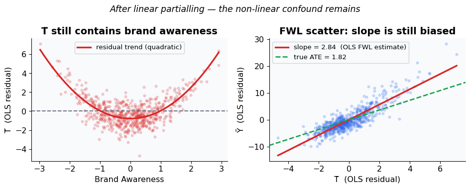

```python
T_tilde_ols = sm.OLS(T, sm.add_constant(X)).fit().resid
Y_tilde_ols = sm.OLS(Y, sm.add_constant(X)).fit().resid

ba_grid = np.linspace(brand_awareness.min(), brand_awareness.max(), 200)

fig, axes = plt.subplots(1, 2, figsize=(10, 4))

ax = axes[0]
ax.scatter(brand_awareness, T_tilde_ols, alpha=0.2, s=12, color="#dc2626")
ax.axhline(0, color="#6b7280", lw=1.5, linestyle="--")
trend = np.polyfit(brand_awareness, T_tilde_ols, 2)
ax.plot(ba_grid, np.polyval(trend, ba_grid), color="#dc2626", lw=2.5,
        label="residual trend (quadratic)")
ax.set_xlabel("Brand Awareness"); ax.set_ylabel("T̃  (OLS residual)")
ax.set_title("T̃ still contains brand awareness", fontweight="bold")
ax.legend(fontsize=10)

ax = axes[1]
ax.scatter(T_tilde_ols, Y_tilde_ols, alpha=0.2, s=12, color="#2563eb")
slope = np.polyfit(T_tilde_ols, Y_tilde_ols, 1)
ax.plot(np.sort(T_tilde_ols), np.polyval(slope, np.sort(T_tilde_ols)),
        color="#dc2626", lw=2.5, label=f"slope = {slope[0]:.2f}  (OLS FWL estimate)")
ax.axline((0,0), slope=tau_true, color="#16a34a", lw=2, linestyle="--",
          label=f"true ATE = {tau_true:.2f}")
ax.set_xlabel("T̃  (OLS residual)"); ax.set_ylabel("Ỹ  (OLS residual)")
ax.set_title("FWL scatter: slope is still biased", fontweight="bold")
ax.legend(fontsize=10)

plt.suptitle("After linear partialling — the non-linear confound remains",
             fontsize=13, fontstyle="italic")
plt.tight_layout()
plt.show()
```

**Tip**

📝 **Read the two diagnostic plots.**

- Left panel: if OLS partialling had worked completely, what shape would you expect in the scatter of T̃ against brand awareness? What do you see instead?
- Right panel: the red line is the OLS FWL estimate; the green dashed line is the true ATE. What does the gap between them represent, and why does it exist?
- What would need to change in the partialling step to make the red line coincide with the green?

## 5 · Manual DML — Cross-Fitted Random Forest

```python
kf    = KFold(n_splits=5, shuffle=True, random_state=42)
T_res = np.zeros(n)
Y_res = np.zeros(n)

for fold, (train_idx, val_idx) in enumerate(kf.split(X)):
    X_train, X_val = X[train_idx], X[val_idx]

    rf_y = RandomForestRegressor(n_estimators=200, max_depth=5, random_state=42)
    rf_t = RandomForestRegressor(n_estimators=200, max_depth=5, random_state=42)
    rf_y.fit(X_train, Y[train_idx])
    rf_t.fit(X_train, T[train_idx])

    Y_res[val_idx] = Y[val_idx] - rf_y.predict(X_val)
    T_res[val_idx] = T[val_idx] - rf_t.predict(X_val)

    print(f"Fold {fold+1}: val size = {len(val_idx)}, "
          f"Y R² = {1 - np.var(Y_res[val_idx])/np.var(Y[val_idx]):.3f}, "
          f"T R² = {1 - np.var(T_res[val_idx])/np.var(T[val_idx]):.3f}")
```

```
Fold 1: val size = 120, Y R² = 0.913, T R² = 0.883
Fold 2: val size = 120, Y R² = 0.882, T R² = 0.798
Fold 3: val size = 120, Y R² = 0.830, T R² = 0.787
Fold 4: val size = 120, Y R² = 0.888, T R² = 0.827
Fold 5: val size = 120, Y R² = 0.896, T R² = 0.804
```

**Tip**

📝 **Understand the cross-fitting loop before moving on.**

- In each fold, the RF is trained on ___ observations and predicts on ___ observations (with 5 folds and n=600).
- Why must the prediction be made on observations the model was *not* trained on?
- The R² values printed are out-of-fold R². What would in-sample R² look like, and why would that be misleading?

```python
tau_dml  = (T_res @ Y_res) / (T_res @ T_res)
sigma2   = np.mean((Y_res - tau_dml * T_res)**2)
se_dml   = np.sqrt(sigma2 / np.sum(T_res**2))
ci_lo    = tau_dml - 1.96 * se_dml
ci_hi    = tau_dml + 1.96 * se_dml

print(f"DML estimate:  £{tau_dml:.3f}k per £1k ad spend")
print(f"Std error:     £{se_dml:.3f}k")
print(f"95% CI:        [£{ci_lo:.3f}k, £{ci_hi:.3f}k]")
print(f"True ATE:      £{tau_true:.3f}k")
print(f"True in CI:    {'✓ Yes' if ci_lo < tau_true < ci_hi else '✗ No'}")
```

```
DML estimate:  £1.901k per £1k ad spend
Std error:     £0.082k
95% CI:        [£1.741k, £2.061k]
True ATE:      £1.817k
True in CI:    ✓ Yes
```

**Tip**

📝 **Interpret the DML output.**

- How close is the DML estimate to the true ATE? How does the bias compare to naïve OLS and OLS with controls?
- The standard error is £___k. In plain language, what does this tell you about the precision of the estimate?
- The 95% CI is [£_**k, £**_k]. Does it contain the true ATE? What would it mean for a marketing decision if the lower bound were negative?

## 6 · The Residual Diagnostic — After DML

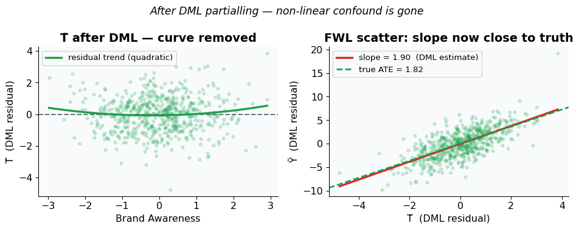

```python
fig, axes = plt.subplots(1, 2, figsize=(10, 4))

ax = axes[0]
ax.scatter(brand_awareness, T_res, alpha=0.2, s=12, color="#16a34a")
ax.axhline(0, color="#6b7280", lw=1.5, linestyle="--")
trend_dml = np.polyfit(brand_awareness, T_res, 2)
ba_grid = np.linspace(brand_awareness.min(), brand_awareness.max(), 200)
ax.plot(ba_grid, np.polyval(trend_dml, ba_grid), color="#16a34a", lw=2.5,
        label="residual trend (quadratic)")
ax.set_xlabel("Brand Awareness"); ax.set_ylabel("T̃  (DML residual)")
ax.set_title("T̃ after DML — curve removed", fontweight="bold")
ax.legend(fontsize=10)

ax = axes[1]
ax.scatter(T_res, Y_res, alpha=0.2, s=12, color="#16a34a")
slope_dml = np.polyfit(T_res, Y_res, 1)
ax.plot(np.sort(T_res), np.polyval(slope_dml, np.sort(T_res)),
        color="#dc2626", lw=2.5, label=f"slope = {slope_dml[0]:.2f}  (DML estimate)")
ax.axline((0,0), slope=tau_true, color="#16a34a", lw=2, linestyle="--",
          label=f"true ATE = {tau_true:.2f}")
ax.set_xlabel("T̃  (DML residual)"); ax.set_ylabel("Ỹ  (DML residual)")
ax.set_title("FWL scatter: slope now close to truth", fontweight="bold")
ax.legend(fontsize=10)

plt.suptitle("After DML partialling — non-linear confound is gone",
             fontsize=13, fontstyle="italic")
plt.tight_layout()
plt.show()
```

**Tip**

📝 **Compare these plots to Section 4.**

- Left panel: how does the shape of T̃ vs brand awareness compare to the OLS version in Section 4? What does this tell you about what the Random Forest learned?
- Right panel: how close is the red line (DML estimate) to the green dashed line (true ATE) now? What changed between Section 4 and here?

## 7 · Estimator Comparison

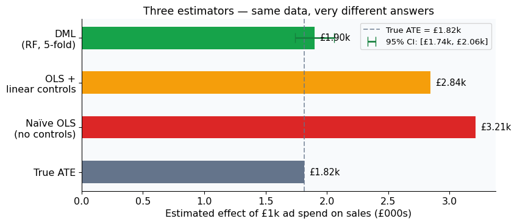

```python
fig, ax = plt.subplots(figsize=(9, 4))

labels = ["True ATE", "Naïve OLS\n(no controls)",
          "OLS +\nlinear controls", "DML\n(RF, 5-fold)"]
values = [tau_true, tau_naive, tau_ctrl, tau_dml]
colors = ["#64748b", "#dc2626", "#f59e0b", "#16a34a"]

bars = ax.barh(labels, values, color=colors, height=0.5)
ax.axvline(tau_true, color="#64748b", linestyle="--", lw=1.5,
           alpha=0.7, label=f"True ATE = £{tau_true:.2f}k")

for bar, val in zip(bars, values):
    ax.text(val + 0.04, bar.get_y() + bar.get_height()/2,
            f"£{val:.2f}k", va="center", fontsize=11)

ax.errorbar(tau_dml, 3, xerr=1.96*se_dml,
            fmt="none", color="#15803d", capsize=6, lw=2,
            label=f"95% CI: [£{ci_lo:.2f}k, £{ci_hi:.2f}k]")

ax.set_xlabel("Estimated effect of £1k ad spend on sales (£000s)")
ax.set_title("Three estimators — same data, very different answers", fontsize=13)
ax.legend(fontsize=10)
plt.tight_layout()
plt.show()
```

**Tip**

📝 **Summarise the comparison in your own words.**

In 2–3 sentences: why do all three estimators see the same data but reach such different conclusions? Which estimator should a marketing manager act on, and why?

## 8 · Inference — What the Numbers Actually Mean

```python
results = pd.DataFrame({
    "Estimator":  ["Naïve OLS", "OLS + controls", "DML"],
    "Estimate":   [tau_naive, tau_ctrl, tau_dml],
    "Bias":       [tau_naive-tau_true, tau_ctrl-tau_true, tau_dml-tau_true],
    "SE":         [None, None, se_dml],
    "CI lower":   [None, None, ci_lo],
    "CI upper":   [None, None, ci_hi],
    "Valid CI":   ["No", "No", "Yes"],
}).round(3)
print(results.to_string(index=False))
```

```
     Estimator  Estimate  Bias    SE  CI lower  CI upper Valid CI
     Naïve OLS     3.213 1.396   NaN       NaN       NaN       No
OLS + controls     2.842 1.026   NaN       NaN       NaN       No
           DML     1.901 0.084 0.082     1.741     2.061      Yes
```

**Tip**

📝 **Why “No” for the first two confidence intervals?**

Naïve OLS and OLS with controls also produce standard errors and confidence intervals automatically. Why do we mark them as invalid, even though the software computes them without complaint?

*Hint: think about what assumptions standard OLS standard errors require, and whether those assumptions hold when there is unremoved confounding in the residuals.*

## 9 · Heterogeneity Preview — Teaser for Week 15

We have been estimating the *average* effect. But the effect is not the same for everyone.

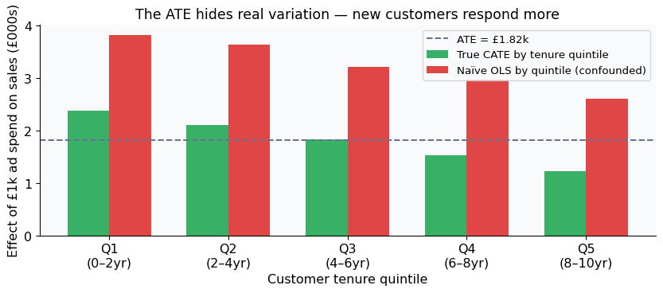

```
True CATE by quintile:
  Q1
(0–2yr): £2.37k
  Q2
(2–4yr): £2.10k
  Q3
(4–6yr): £1.84k
  Q4
(6–8yr): £1.54k
  Q5
(8–10yr): £1.23k
```

```python
tenure_quintile = pd.qcut(customer_tenure, q=5,
                           labels=["Q1\n(0–2yr)", "Q2\n(2–4yr)", "Q3\n(4–6yr)",
                                   "Q4\n(6–8yr)", "Q5\n(8–10yr)"])

true_by_quintile = pd.Series(tau_i).groupby(tenure_quintile).mean()

naive_by_quintile = []
for q in true_by_quintile.index:
    mask = tenure_quintile == q
    m = sm.OLS(Y[mask], sm.add_constant(pd.Series(T[mask], name="T"))).fit()
    naive_by_quintile.append(m.params["T"])

fig, ax = plt.subplots(figsize=(9, 4))
x = np.arange(5)
w = 0.35
ax.bar(x - w/2, true_by_quintile, w, color="#16a34a", alpha=0.85,
       label="True CATE by tenure quintile")
ax.bar(x + w/2, naive_by_quintile, w, color="#dc2626", alpha=0.85,
       label="Naïve OLS by quintile (confounded)")
ax.axhline(tau_true, color="#64748b", linestyle="--", lw=1.5,
           label=f"ATE = £{tau_true:.2f}k")
ax.set_xticks(x)
ax.set_xticklabels(true_by_quintile.index)
ax.set_xlabel("Customer tenure quintile")
ax.set_ylabel("Effect of £1k ad spend on sales (£000s)")
ax.set_title("The ATE hides real variation — new customers respond more",
             fontsize=13)
ax.legend(fontsize=10)
plt.tight_layout()
plt.show()

print("True CATE by quintile:")
for q, v in true_by_quintile.items():
    print(f"  {q}: £{v:.2f}k")
```

**Tip**

📝 **Think about what this means for marketing decisions.**

- The ATE is £1.82k. For new customers (Q1), the true effect is £_**k. For loyal customers (Q5), it is £**_k.
- If you had to allocate a fixed ad budget across customer segments, what would this heterogeneity imply?
- The naïve quintile-level OLS (red bars) is still confounded. What does this tell you about the limits of stratified analysis as an alternative to causal methods?
- This is called the **Conditional Average Treatment Effect (CATE)**. How does it differ from the ATE, and when would you prefer one over the other?

## 10 · Bonus — `econml` LinearDML

```python
from econml.dml import LinearDML
from sklearn.ensemble import RandomForestRegressor

model_y = RandomForestRegressor(n_estimators=200, max_depth=5, random_state=42)
model_t = RandomForestRegressor(n_estimators=200, max_depth=5, random_state=42)

dml = LinearDML(
    model_y            = model_y,
    model_t            = model_t,
    discrete_treatment = False,
    cv                 = 5,
    random_state       = 42
)
dml.fit(Y, T, X=X)

ate       = dml.ate(X)
ate_lo, ate_hi = dml.ate_interval(X, alpha=0.05)

print(f"econml LinearDML ATE:  £{ate:.3f}k")
print(f"95% CI:                [£{ate_lo:.3f}k, £{ate_hi:.3f}k]")
print(f"Manual DML estimate:   £{tau_dml:.3f}k  (for comparison)")
```

**Tip**

📝 **The `econml` estimate should closely match the manual DML estimate.**

- Why might they not be *exactly* identical, even though both use 5-fold cross-fitting with the same learner?
- What does `econml` add beyond what we implemented manually? Why would you use the library in practice rather than the manual loop?
- `eval: false` means this cell does not run automatically. To run it: `uv add econml` in the repo root, then set `eval: true`.

## Summary

```python
print("=" * 60)
print(f"  True ATE:              £{tau_true:.3f}k")
print("=" * 60)
print(f"  Naïve OLS:             £{tau_naive:.3f}k  (bias: {tau_naive-tau_true:+.3f}k)")
print(f"  OLS + linear controls: £{tau_ctrl:.3f}k  (bias: {tau_ctrl-tau_true:+.3f}k)")
print(f"  DML (manual, RF):      £{tau_dml:.3f}k  (bias: {tau_dml-tau_true:+.3f}k)")
print(f"  95% CI:                [£{ci_lo:.3f}k, £{ci_hi:.3f}k]")
print("=" * 60)
```

```
============================================================
  True ATE:              £1.817k
============================================================
  Naïve OLS:             £3.213k  (bias: +1.396k)
  OLS + linear controls: £2.842k  (bias: +1.026k)
  DML (manual, RF):      £1.901k  (bias: +0.084k)
  95% CI:                [£1.741k, £2.061k]
============================================================
```

**Tip**

📝 **Final reflection — three things to carry into Week 15.**

Before leaving this notebook, write one sentence for each:

1. **ATE vs CATE:** The ATE is a single number (£1.82k). Why is it sometimes insufficient for a marketing decision?
2. **Why DML works:** What specifically does cross-fitting do that makes DML’s confidence interval trustworthy when OLS’s is not?
3. **The FWL connection:** DML is described as “FWL with ML partialling.” In your own words, what is the same between DML and FWL, and what is different?

*Next week: same DGP, same logic — but instead of one number, we estimate τ(x): the effect as a function of customer characteristics.*